# Lesson 12: Inference for Two Means (Paired Data)

Preparation

- Word Document
- PDF Document

## Solutions

Problem

Part

Solution

1

-

Usually matched pairs are data taken from one population where a pair of observations is drawn on the same individuals selected for the sample, such as a pre-test and post-test.

2

-

open ended

3

A

After implementing the new loading/unloading procedure, is the mean wait time different than the wait time before?

3

B

$H_o:\mu_d =$ 0  
$H_a:\mu_d\neq$ 0

4

-

The researcher collected assembly times (in minutes) from 9 factory workers before the change. Then he collected the assembly times for those same 9 workers after the change in procedure had been implemented.

5

-

The paragraph should include:  
- $\bar{d}=\pm$ 1.056 (depending on difference taken)  
- $s_d =$ 2.596  
- $n=$ 9  
- One histogram of the differences and one histogram for each of the original data sets with clear lables.

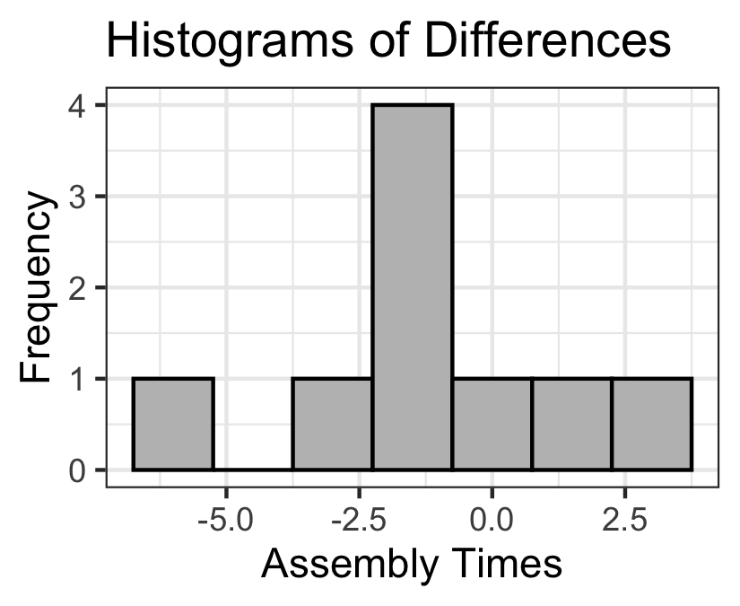

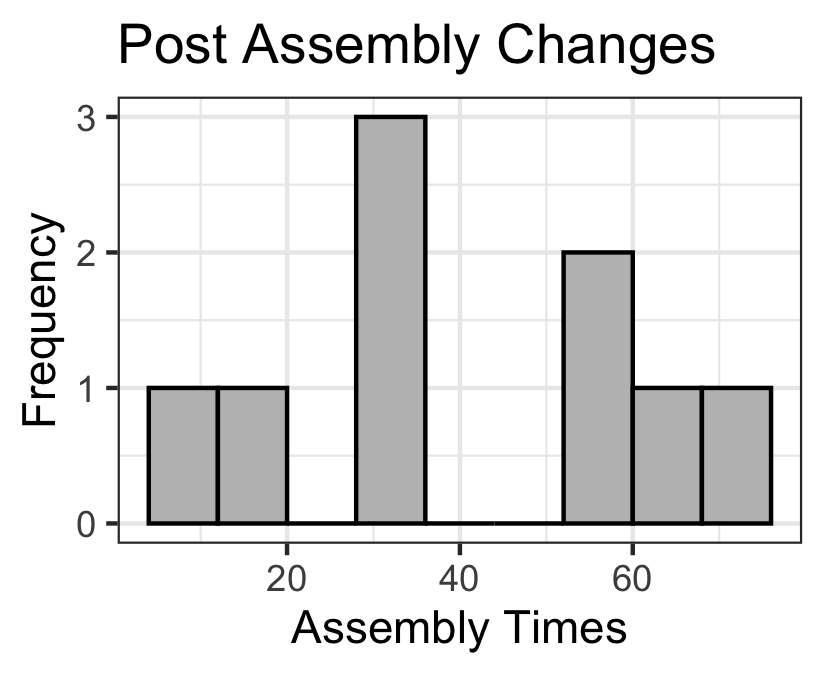

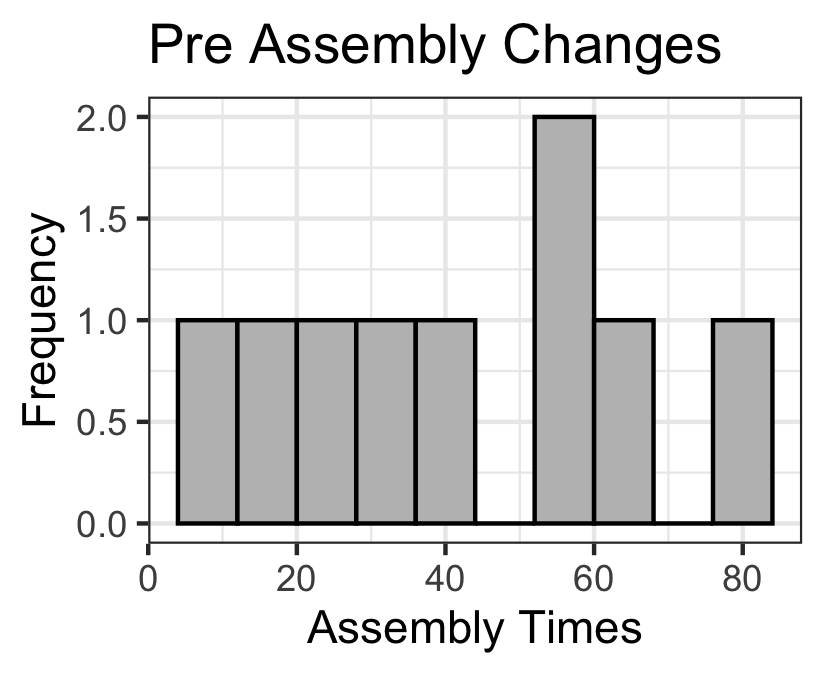

6

A

A two tailed paired-sample t-test for means is the appropriate hypothesis test to perform.

6

B

That the sample mean of the differences comes from a normal distribution and we assume a simple random sample of the population.

6

C

We assume a simple random sample of the population. $n < 30$ so we would need to look back at the histogram to determine normality of the data.

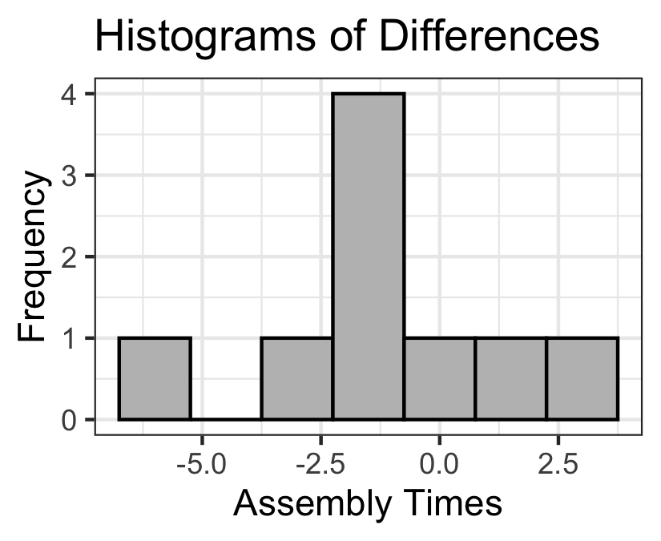

The differences may not by normally distributed, it is hard to tell with such a small sample size. We will continue with our assumption of normality.

6

D

$t=1.22$ or $t=-1.22$

6

E

$df=8$

6

F

$\text{P-value}=0.257\text{ P-value}>\alpha$

6

G

$\text{P-value} > \alpha$, therefore we fail to reject the null hypothesis the null hypothesis.

6

H

We have insufficient evidence to say that the time to make 100 products is any different after the implementation of the new assembly procedure.

6

I

We would create a 95% confidence interval using the t-distribution. (-0.9397,3.0508) or (-3.0508,0.9397) depending on difference calculated

7

-

You should describe how they need to find another way to reduce the time, because this particular plan did not make a statistically significant difference.